# K-Means Clustering

Julia Hartnett

# Introduction

K-Means Clustering is a widely used clustering algorithm. Clustering is a way to identify patterns in data and create groups accordingly. Data points with similar attributes will fall close to each other and into the same cluster, and therefore will be classified as the same category.Specifically, K-Means clustering works by randomly selecting points to be the center of a cluster, classifying points to fall into the cluster they are closest to, recalculating the cluster mean (center), and then classifying points again to be the cluster they are closest to. The “K” in K-Means stands for the number of clusters the data should be grouped into. K is chosen by the person running the algorithm, and can be a trial and error decision. To show K-Means CLustering, I will first do a simple example by hand and then move to a more complicated example using the actual algorithm. After, I will compare how K-Means performs on my data versus a decision tree.

# Perform K-Means Clustering on Contrived Data

To begin with k-means clustering, we first need to load some packages.

```r
#Load packages
library(tidyverse)
library(cluster)
library(tidymodels)
library(rpart)
```

First, I am going to create a sample data set. To keep this section simple, the data set is just going to be a collection of XY coordinates. Clustering is still appropriate here because we are able to find a center of a group of coordinates and assign clusters relative to the distance between the points and the centroid. This is an example of unsupervised learning, as the group labels are not part of our data and instead are something we are trying to create.

```r
#Create a small data frame
col1 = c("a", "b", "c", "d", "e")
col2 = c(1 , 1, 0, 2, 3)
col3 = c(1, 0, 2, 4, 5)
df = data.frame(col1, col2, col3)
colnames(df) = c("i", "X", "Y")

df
```

| i | X | Y |
| --- | --- | --- |
| a | 1 | 1 |
| b | 1 | 0 |
| c | 0 | 2 |
| d | 2 | 4 |
| e | 3 | 5 |

Let’s make a quick graph for some exploratory data analysis.

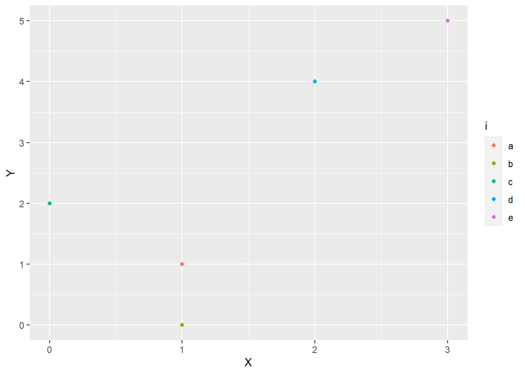

```r
ggplot(aes(x = X, y = Y), data = df) +
  geom_point(aes(color = i))
```

To put these points into groups, R will randomly select two points to be the original cluster centers. I am going to make two clusters, so let’s randomly select two points.

```r
set.seed(20)
sample(df$i, 2, replace = FALSE)
```

```
## [1] "c" "d"
```

My first two cluster centers will be Point C, the green point at (0,2) and Point D, the blue point at (2,4).

The next step is to compute the distance between each of the cluster means and all of the other points. I will use euclidean distance. My data isn’t set up well enough to use the built in distnace function, so I will quickly do these out.

## Distnace Calculations

Point A (1,1):

From group 1 (0,2):

```r
a1 = sqrt((0 - 1)^2 + (2 - 1)^2)
a1
```

```
## [1] 1.414214
```

From group 2 (2,4):

```r
a2 = sqrt((2 - 1)^2 + (4 -1)^2)
a2
```

```
## [1] 3.162278
```

Point B (1,0):

From group 1 (0,2):

```r
b1 = sqrt((0 - 1)^2 + (2 - 0)^2)
b1
```

```
## [1] 2.236068
```

From group 2 (2,4):

```r
b2 = sqrt((2 - 1)^2 + (4 -0)^2)
b2
```

```
## [1] 4.123106
```

Point C (0,2):

From group 1 (0,2):

```r
c1 = sqrt((0 - 0)^2 + (2 - 2)^2)
c1
```

```
## [1] 0
```

From group 2 (2,4):

```r
c2 = sqrt((2 - 0)^2 + (4 -2)^2)
c2
```

```
## [1] 2.828427
```

Point D (2,4):

From group 1 (0,2):

```r
d1 = sqrt((0 - 2)^2 + (2 - 4)^2)
d1
```

```
## [1] 2.828427
```

From group 2 (2,4):

```r
d2 = sqrt((2 - 2)^2 + (4 -4)^2)
d2
```

```
## [1] 0
```

Point E (3,5):

From group 1 (0,2):

```r
e1 = sqrt((0 - 3)^2 + (2 - 5)^2)
e1
```

```
## [1] 4.242641
```

From group 2 (2,4):

```r
e2 = sqrt((2 - 3)^2 + (4 -5)^2)
e2
```

```
## [1] 1.414214
```

# Back to clustering

Let’s make a data frame of the distances.

```r
distance1 = data.frame(col1, col2 = c(a1, b1, c1, d1, e1), col3 = c(a2, b2, c2, d2, e2))
colnames(distance1) = c("i", "Group 1", "Group 2")
distance1
```

| i | Group 1 | Group 2 |
| --- | --- | --- |
| a | 1.414214 | 3.162278 |
| b | 2.236068 | 4.123106 |
| c | 0.000000 | 2.828427 |
| d | 2.828427 | 0.000000 |
| e | 4.242641 | 1.414214 |

Now that we have the distances, we can determine which group each point belongs to by seeing which distance value is the smallest. We can see that points A, B, and C belong to Group 1 and points D and E belong to Group 2.

We can now recalculate the mean of each of the clusters to get a new center.

For Group 1:

```r
(1 + 1 + 0)/ 3
```

```
## [1] 0.6666667
```

```r
(1 + 0 + 2)/3
```

```
## [1] 1
```

The new center is at (0.7, 1)

For Group 2:

```r
(2 + 3)/ 2
```

```
## [1] 2.5
```

```r
(4 + 5)/ 2
```

```
## [1] 4.5
```

The new center is at (2.5, 4.5)

Let’s add these points to our plot from before.

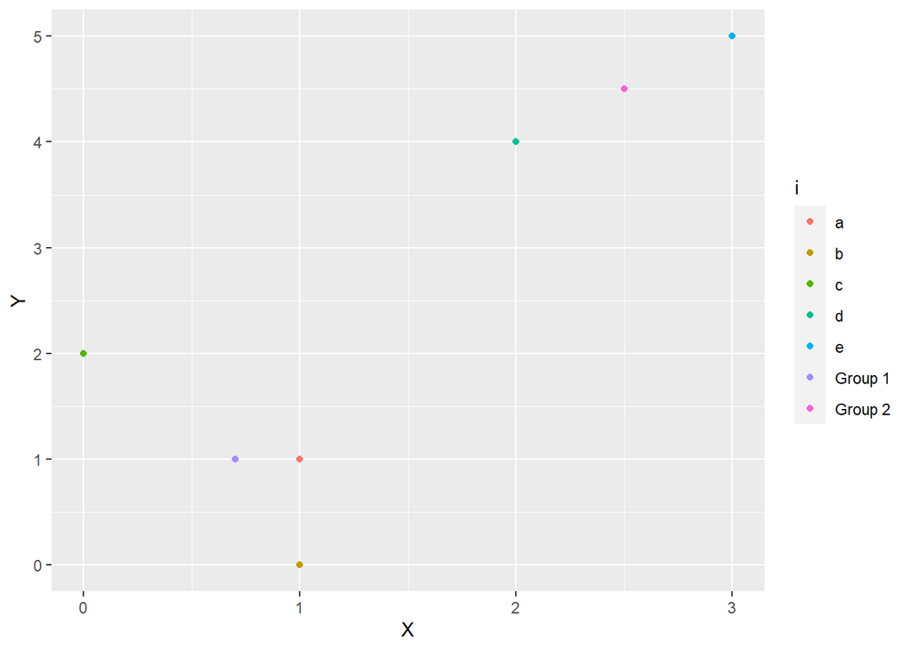

```r
col1 = c("a", "b", "c", "d", "e", "Group 1", "Group 2")
col2 = c(1 , 1, 0, 2, 3, 0.7, 2.5)
col3 = c(1, 0, 2, 4, 5, 1, 4.5)
df2 = data.frame(col1, col2, col3)
colnames(df2) = c("i", "X", "Y")

ggplot(aes(x = X, y = Y), data = df2) +
  geom_point(aes(color = i))
```

The next step is to repeat this assignment process by finding the difference between each of the points and the new cluster mean, and then assigning the points to the group which it is closest to. However, it is clear that these groups are not going to change and that these are the most optimal clusters. The important output of our model are the centroid values and the points that belong to each cluster. The centroids allow us to classify new unseen points, and the groups reval important patterns in our data.

# K-Means Clustering on Spotify Data

To demonstrate K-Means Clustering on real world data, I will be using the spotify_ssongs dataset available from tidytuesday (https://github.com/rfordatascience/tidytuesday/blob/master/data/2020/2020-01-21/readme.md). The dependent value here, the column we are trying to predict, is ‘playlist_genre’. ‘playlist_genre’ is a categorical variable made up of 6 levels: edm, latin, pop, r&b, rap, and rock. The question of interest is if we can use the provided attributes to group songs into clusters, and if those clusters will consist of one genre. The attributes I will use are:

- -danceability’ - Describes how suitable a track is for dancing based on a combination of musical elements including tempo, rhythm stability, beat strength, and overall regularity. A value of 0.0 is least danceable and 1.0 is most danceable
- ‘energy’ - A measure from 0.0 to 1.0 and represents a perceptual measure of intensity and activity
- ‘speechiness’ - Detects the presence of spoken words in a track.The more exclusively speech-like the recording (e.g. talk show, audio book, poetry), the closer to 1.0 the attribute value.
- ‘acousticness’ - A confidence measure from 0.0 to 1.0 of whether the track is acoustic.
- ‘instrumentalness’ - Predicts whether a track contains no vocals. The closer the instrumentalness value is to 1.0, the greater likelihood the track contains no vocal content.
- ‘liveness’ - Detects the presence of an audience in the recording. Higher liveness values represent an increased probability that the track was performed live.
- ‘valence’ - A measure from 0.0 to 1.0 describing the musical positiveness conveyed by a track.
- ‘tempo’ - The overall estimated tempo of a track in beats per minute (BPM).

## Data Input Manipulations

All of the above variables, other than tempo, are measured on a 0-1 scale. Tempo is measured in BPM. To account for this, I will scale all of the above columns before clustering. The data set does not appear to have any missing values, and the amount of songs of each genre appears to be roughly similar, as seen in the output below. Therefore, I do not need to do any data balancing. Because this is an unsupervised learning method, cross validation would not be beneficial.

```r
#Load in the data
spotify_songs <- readr::read_csv('https://raw.githubusercontent.com/rfordatascience/tidytuesday/master/data/2020/2020-01-21/spotify_songs.csv')
spotify_songs %>%
  count(playlist_genre)
```

| playlist_genre | n |
| --- | --- |
| edm | 6043 |
| latin | 5155 |
| pop | 5507 |
| r&b | 5431 |
| rap | 5746 |
| rock | 4951 |

After considering any possible data input manipulations, we can now move onto clustering.

## Clustering Algorithm

```r
set.seed(20)

spotify_songs_new = spotify_songs %>%
  select(playlist_genre, danceability, energy, speechiness, acousticness, instrumentalness, liveness, valence, tempo) #select only the columns we are interested in

spotify_songs_new[c(2,3,4,5,6,7,8,9)] <- lapply(spotify_songs_new[c(2,3,4,5,6,7,8,9)], function(x) c(scale(x))) #scale all of the numeric columns


dat <- spotify_songs_new[, -1] # without known classification

clus <- kmeans(dat, centers=6) #perform kmeans with 6 clusters

clus$centers
```

```
##   danceability     energy  speechiness acousticness instrumentalness   liveness
## 1   0.58128554  0.1416130 -0.326839528  -0.17975891      -0.30904064 -0.2756046
## 2   0.49484719 -0.1881963  2.015805698   0.03295668      -0.32734731 -0.1006782
## 3   0.04663351  0.4004734 -0.348435642  -0.40064492       2.97451354 -0.1119071
## 4  -0.32298902  0.4457080  0.004852103  -0.27778048      -0.14995712  2.6687597
## 5  -0.34061777 -1.4665242 -0.344312887   1.83741996      -0.02095428 -0.2794960
## 6  -0.76090538  0.3983743 -0.368889411  -0.49454837      -0.27313657 -0.1344215
##        valence       tempo
## 1  0.745735988 -0.25782006
## 2  0.149823593  0.07355810
## 3 -0.536606423  0.14658551
## 4  0.002127799  0.02524059
## 5 -0.520049972 -0.36746924
## 6 -0.613775319  0.41915640
```

```r
clus$size
```

```
## [1] 10856  4468  2546  2263  4174  8526
```

```r
table(clus$cluster, spotify_songs_new$playlist_genre)
```

```
##
##      edm latin  pop  r&b  rap rock
##   1 1258  2794 2105 2024 1387 1288
##   2  304   620  260  871 2371   42
##   3 1454   194  285  102  276  235
##   4  579   307  312  292  332  441
##   5  203   543  770 1424  580  654
##   6 2245   697 1775  718  800 2291
```

## Analysis and Evaluation

The output of the model itself gives us the size of each cluster and the cluster means. It also gives us some other information, such as the within cluster sum of squares value for each cluster, but this extra information is not very important right now. By running the table command on the cluster model, we can see how many songs of each genre fall into each cluster. Again because this is unsupervised learning, the clusters were created without the algorithm considering the genre of the song associated with the other data it was given. By seeing how many songs of each category fall into each cluster, we can manually assign a label to each group.

Cluster 1: latin Cluster 2: rap Cluster 3: edm Cluster 4: edm Cluster 5: r&b Cluster 6: rock

It is interesting that edm takes the majority in two clusters, possibly meaning that there are dramatic differences within the genre of edm. It is also interesting that pop is not the majority in any of the clusters, therefore no song would be classified as pop using these groupings. The counts also show that the clusters really are a mix of each genre. These cluster plots below show that as well. I really like the second plot, and how clear it shows the differences between some of the groups (group 2 - rap - is very distinct) and how other groups (1, 4) are completely muddled together.

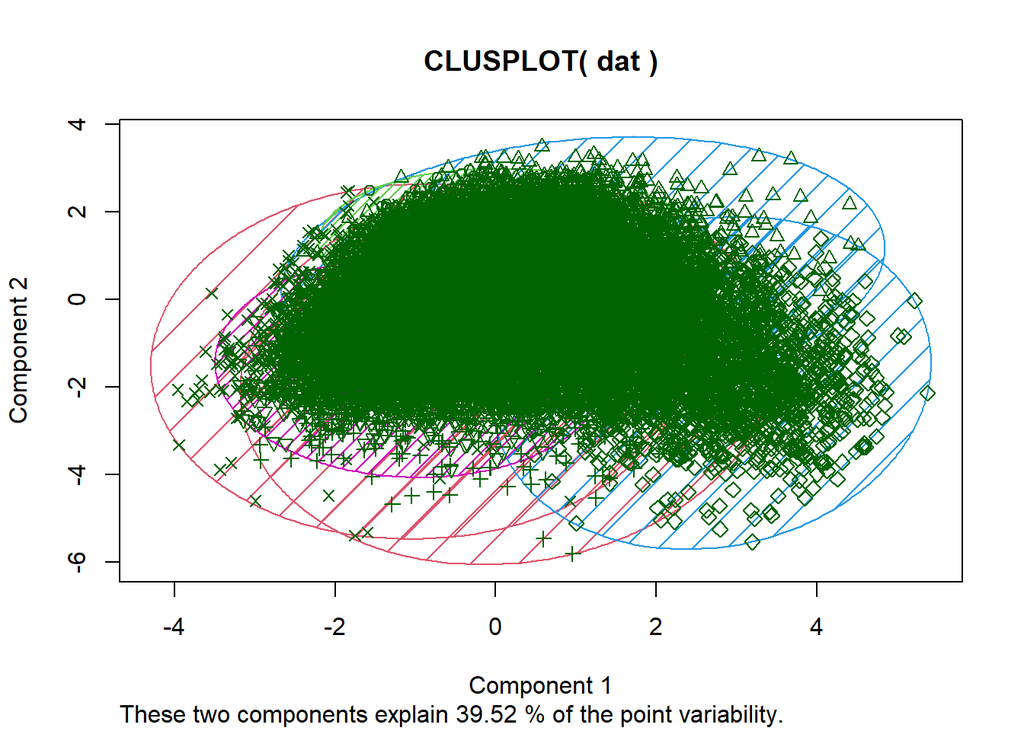

```r
clusplot(dat, clus$cluster, color=TRUE, shade=TRUE, labels = 0)
```

```r
set.seed(20)
library(fpc)
```

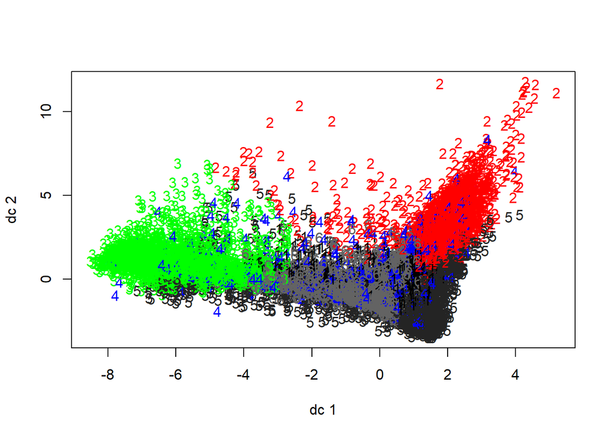

```r
plotcluster(dat, clus$cluster)
```

To evaluate the clustering algorithm, we can calculate the Probability of Error. To do this, I will assign each cluster to be its majority category and anything else in that category is considered an error.

```r
#Cluster 1 - latin

(1258 + 2105 + 2024 + 1387 + 1288)/(1258 + 2105 + 2024 + 1387 + 1288 + 2794)
```

```
## [1] 0.7426308
```

```r
#Cluster 2 - rap
(304 + 620 + 260 + 871 + 42)/(304 + 620 + 260 + 871 + 42 + 2371)
```

```
## [1] 0.4693375
```

```r
#Cluster 3 - edm

(194 + 285 + 102 + 276 + 235)/(194 + 285 + 102 + 276 + 235 + 1454)
```

```
## [1] 0.4289081
```

```r
#Cluster 4 - edm

(307 + 312 + 292 + 332 + 441)/(307 + 312 + 292 + 332 + 441 + 579)
```

```
## [1] 0.7441449
```

```r
#Cluster 5 - r&b

(203 + 543 + 770 + 580 + 654)/(203 + 543 + 770 + 580 + 654 + 1424)
```

```
## [1] 0.6588404
```

```r
#Cluster 6 - rock

(2245 + 697 + 1775 + 718 + 800)/(2245 + 697 + 1775 + 718 + 800 + 2291)
```

```
## [1] 0.7312925
```

Finding the weighted probability of error:

```r
 n = 10856 +  4468 + 2546 + 2263 + 4174 + 8526 #total number of songs in data, also the number of songs in each cluster

((0.7426308)*(10856/n)) + ((0.4693375)*(4468/n)) + ((0.4289081)*(2546/n)) + ((0.7441449)*(2263/n)) + ((0.6588404)*(4174/n)) + ((0.7312925)*(8526/n))
```

```
## [1] 0.667621
```

Our model has an overall probability of error of 66.76%, so it was 33.24% accurate.

## Classify New Instance

To classify a new instance, our model will take the new data point and compare the point to the center of each cluster. The cluster mean to which the point has the shortest distance is the cluster the point will be classified as.

Generating a random point:

```r
set.seed(20)
runif(8, -1, 1) #generate 8 random points between -1 and 1 since our data was scaled
```

```
## [1]  0.75504278  0.53706642 -0.44207372  0.05832739  0.92581406  0.96070917
## [7] -0.81733482 -0.85850104
```

Compare this point to each of the cluster means:

```r
#Cluster 1
sqrt((0.58128554 - 0.75504278)^2 + (0.1416130 - 0.53706642)^2 + (-0.326839528 - -0.44207372)^2 + (-0.17975891 - 0.05832739)^2 + (-0.30904064 - 0.92581406)^2 + (-0.2756046 - 0.96070917)^2 + (0.745735988 - -0.81733482)^2 + (-0.25782006 - -0.85850104)^2)
```

```
## [1] 2.472627
```

```r
#Cluster 2
sqrt((0.49484719 - 0.75504278)^2 + (-0.1881963 - 0.53706642)^2 + (2.015805698 - -0.44207372)^2 + (0.03295668 - 0.05832739)^2 + (-0.32734731 - 0.92581406)^2 + (-0.1006782 - 0.96070917)^2 + (0.149823593  - -0.81733482)^2 + (0.07355810 - -0.85850104)^2)
```

```
## [1] 3.337156
```

```r
#Cluster 3
sqrt((0.04663351 - 0.75504278)^2 + (0.4004734 - 0.53706642)^2 + (-0.348435642 - -0.44207372)^2 + (-0.40064492 - 0.05832739)^2 + (2.97451354 - 0.92581406)^2 + (-0.1119071 - 0.96070917)^2 + (-0.536606423 - -0.81733482)^2 + (0.14658551 - -0.85850104)^2)
```

```
## [1] 2.678919
```

```r
#Cluster 4
sqrt((-0.32298902 - 0.75504278)^2 + (0.4457080 - 0.53706642)^2 + (0.004852103 - -0.44207372)^2 + (-0.27778048 - 0.05832739)^2 + (-0.14995712 - 0.92581406)^2 + (2.6687597 - 0.96070917)^2 + (0.002127799 - -0.81733482)^2 + (0.02524059 - -0.85850104)^2)
```

```
## [1] 2.647725
```

```r
#Cluster 5
sqrt((-0.34061777 - 0.75504278)^2 + (-1.4665242 - 0.53706642)^2 + (-0.344312887 - -0.44207372)^2 + (1.83741996 - 0.05832739)^2 + (-0.02095428 - 0.92581406)^2 + (-0.2794960 - 0.96070917)^2 + (-0.520049972 - -0.81733482)^2 + (-0.36746924 - -0.85850104)^2)
```

```
## [1] 3.339692
```

```r
#Cluster 6
sqrt((-0.76090538 - 0.75504278)^2 + (0.3983743 - 0.53706642)^2 + (-0.368889411 - -0.44207372)^2 + (-0.49454837 - 0.05832739)^2 + (-0.27313657 - 0.92581406)^2 + (-0.1344215 - 0.96070917)^2 + (-0.613775319 - -0.81733482)^2 + (0.41915640 - -0.85850104)^2)
```

```
## [1] 2.634198
```

Our new point is closest to the center of cluster 1, and therefore would be classified as latin.

# Using a Decision Tree on Spotify Data

To compare our clustering algorithm to another model, I will build a decision tree. A decision tree is an appropriate choice because it uses the attributes to attempt to group the data into leaves of similar instances. If one leaf consists of only one class, it is a pure leaf. For a decision tree, we need to split our data into a training and testing set, fit the model on the training set, and then run it on the testing set.

```r
set.seed(20)
data_split = initial_split(spotify_songs_new, prop = 0.8)
data_train = training(data_split)
data_test = testing(data_split)
```

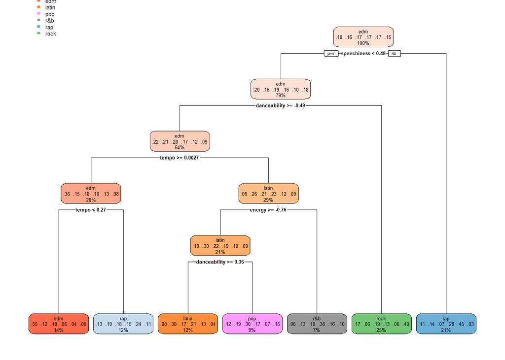

```r
fit <- rpart(playlist_genre ~ danceability + energy + speechiness + acousticness + instrumentalness + liveness + valence + tempo,
             method="class", data=data_train)
rpart.plot::rpart.plot(fit)
```

```r
predict_unseen <-predict(fit, data_test, type = 'class')
table_mat <- table(data_test$playlist_genre, predict_unseen)
table_mat
```

```
##        predict_unseen
##         edm latin pop r&b rap rock
##   edm   499    66  62  23 270  314
##   latin 110   305 108  72 349   82
##   pop   163   142 166  84 238  291
##   r&b    52   151 109 151 412  197
##   rap    30   110  29  65 818  102
##   rock   49    25 100  66 116  640
```

Looking down the columns in the table, we can see that the largest value in the column has matching column and row labels, which is a reassuring sign that the model did alright at predicting the playlist genre.

```r
accuracy_Test <- sum(diag(table_mat)) / sum(table_mat)
accuracy_Test
```

```
## [1] 0.392781
```

# Sources

https://statsandr.com/blog/clustering-analysis-k-means-and-hierarchical-clustering-by-hand-and-in-r/

https://stats.stackexchange.com/questions/31083/how-to-produce-a-pretty-plot-of-the-results-of-k-means-cluster-analysis

https://rdrr.io/cran/cluster/man/clusplot.default.html

https://www.guru99.com/r-decision-trees.html